# Predicting Post-fight Winning Streaks of UFC Fighters

## Phase 2: Statistical Modelling

#### Group Name: 92

#### Name(s) & ID(s) of Group Members:

## - Myeonghoon - s3774430

- Introduction
  - Phase 1 Summary
  - Report Overview
  - Overview of Methodology
- Statistical Modelling
  - Model Overview
  - Model Fitting
- Critique & Limitations
- Summary and Conclusion
  - Project Summary
  - Summary of Findings
  - Conclusions
- References

## Introduction

### Phase 1 Summary

In Phase 1, the raw dataset underwent a cleaning process, which resulted in two formats of `DataFrame` (one with outliers present, the other without). In the process, we also created a dependent variable derived from two existing features (We naively decided to keep one of the independent features for Phase 2 only to learn to drop it since it is a good practice to drop all features used to derive a response feature). We visualised the interplay between various features by means of plots. However, we lacked a definite equation to elucidate obscure correlations between the dependent and independent features. In Phase 2, we will generate the equation for each of our models, which will be used to predict values of the response feature as intended in Phase 1.

### Report Overview

We start by outlining the methodology used for fitting our datasets (one with outliers, the other without) into multiple linear regression models; we take the approach of using two datasets to build respective models and selecting the one with outliers present if the conclusions are the same.

After generating our full models, we will analyse the results and run diagnostics to check for any violation of model assumptions. We will then conduct feature selection to produce our reduced models, which will be also analysed and examined in the same manner as in the case of full models.

We will then discuss the limitations of our models and critique their results. Next, we will summarise the entire project and its findings. Lastly we finish the report by drawing conclusions with respect to our goals and objectives.

### Overview of Methodology

Each of our datasets contains 134 features used to make predictions with respect to our dependent feature `r_post_fight_win_streak`. With this many "independent" features from observational data, our models run the risk of being influenced by multicollinearity. We will address this potential problem by removing features with the Variance Inflation Factors (VIFs) larger than 5. We are going to mitigate severe multicollinearity since our goal is both to make predictions and to understand the impact of each independent variable (Frost, n.d.). We then build our full models. After that, we run diagnostics to check whether the model assumptions are met. We then perform backward elimination with the p-value approach to select the predictors that help increase the strength of our model fit. We will then again confirm that the model conditions are met for the second time.

## Statistical Modelling

### Full Model Overview

As stated above, we will filter out features under the influence of multicollinearity before building our full models, each of which contains the remaining features without any interaction terms appended.

1. Full Model with Outliers ($R_{adj}^{2}$: 0.332)

$$\hat{r\_post\_fight\_win\_streak} = 0.683 + title\_bout \times 1.639 + b\_avg\_kd \times -0.005 + b\_avg\_opp\_kd \times 0.032 + b\_avg\_sig\_str\_pct \times 0.213 + b\_avg\_opp\_sig\_str\_pct \times -0.146 + b\_avg\_td\_pct \times -0.07 + b\_avg\_opp\_td\_pct \times 0.111 + b\_avg\_sub\_att \times -0.018 + b\_avg\_opp\_sub\_att \times 0.052 + b\_avg\_rev \times 0.033 + b\_avg\_opp\_rev \times -0.061 + b\_avg\_td\_att \times -0.06 + b\_avg\_opp\_td\_att \times -0.034 + b\_avg\_opp\_td\_landed \times 0.0 + b\_avg\_head\_landed \times -0.003 + b\_avg\_opp\_head\_landed \times 0.005 + b\_avg\_body\_landed \times -0.009 + b\_avg\_opp\_body\_landed \times 0.008 + b\_avg\_leg\_att \times -0.007 + b\_avg\_opp\_leg\_att \times 0.002 + b\_avg\_opp\_clinch\_landed \times 0.004 + b\_avg\_ground\_att \times -0.004 + b\_avg\_opp\_ground\_att \times -0.003 + b\_avg\_ctrl\_time\_seconds \times 0.001 + b\_avg\_opp\_ctrl\_time\_seconds \times 0.0 + b\_total\_title\_bouts \times 0.004 + b\_current\_win\_streak \times -0.058 + b\_current\_lose\_streak \times -0.106 + b\_losses \times 0.009 + b\_draw \times -0.038 + b\_win\_by\_decision\_majority \times 0.242 + b\_win\_by\_decision\_split \times 0.068 + b\_win\_by\_decision\_unanimous \times -0.025 + b\_win\_by\_ko\_tko \times 0.002 + b\_win\_by\_submission \times 0.031 + b\_win\_by\_tko\_doctor\_stoppage \times 0.139 + b\_reach\_cms \times -0.005 + r\_avg\_kd \times 0.178 + r\_avg\_opp\_kd \times -0.316 + r\_avg\_sig\_str\_pct \times 0.325 + r\_avg\_opp\_sig\_str\_pct \times -1.471 + r\_avg\_td\_pct \times -0.017 + r\_avg\_opp\_td\_pct \times 0.017 + r\_avg\_sub\_att \times 0.173 + r\_avg\_opp\_sub\_att \times 0.003 + r\_avg\_rev \times -0.218 + r\_avg\_opp\_rev \times 0.11 + r\_avg\_td\_att \times 0.001 + r\_avg\_opp\_td\_att \times 0.058 + r\_avg\_opp\_td\_landed \times -0.07 + r\_avg\_head\_landed \times 0.005 + r\_avg\_opp\_head\_att \times -0.005 + r\_avg\_body\_landed \times 0.001 + r\_avg\_opp\_body\_landed \times 0.006 + r\_avg\_leg\_landed \times 0.021 + r\_avg\_opp\_leg\_landed \times -0.004 + r\_avg\_clinch\_landed \times -0.002 + r\_avg\_opp\_clinch\_att \times -0.004 + r\_avg\_ground\_att \times 0.01 + r\_avg\_opp\_ground\_att \times 0.005 + r\_avg\_ctrl\_time\_seconds \times 0.001 + r\_avg\_opp\_ctrl\_time\_seconds \times -0.001 + r\_total\_title\_bouts \times 0.046 + r\_current\_lose\_streak \times -0.184 + r\_losses \times -0.204 + r\_draw \times -0.052 + r\_win\_by\_decision\_majority \times -0.333 + r\_win\_by\_decision\_split \times 0.084 + r\_win\_by\_decision\_unanimous \times 0.119 + r\_win\_by\_ko\_tko \times 0.134 + r\_win\_by\_submission \times 0.177 + r\_win\_by\_tko\_doctor\_stoppage \times 0.047 + r\_reach\_cms \times 0.012 + b\_age \times 0.019 + r\_age \times -0.02 + weight\_class_{CatchWeight} \times -0.349 + weight\_class_{Featherweight} \times 0.181 + weight\_class_{Flyweight} \times 0.211 + weight\_class_{Heavyweight} \times -0.263 + weight\_class_{LightHeavyweight} \times -0.01 + weight\_class_{Lightweight} \times 0.069 + weight\_class_{Middleweight} \times 0.003 + weight\_class_{Welterweight} \times -0.086 + weight\_class_{WomenBantamweight} \times -0.024 + weight\_class_{WomenFeatherweight} \times 0.415 + weight\_class_{WomenFlyweight} \times 0.016 + weight\_class_{WomenStrawweight} \times 0.083 + b\_stance_{Southpaw} \times 0.004 + b\_stance_{Switch} \times -0.263 + r\_stance_{Southpaw} \times 0.018 + r\_stance_{Switch} \times 0.229 $$

1. Full Model Without Outliers ($R_{adj}^{2}$: 0.266) $$\hat{r\_post\_fight\_win\_streak} = 4.3 + b\_avg\_kd \times -0.07 + b\_avg\_opp\_kd \times 0.063 + b\_avg\_sig\_str\_pct \times 0.555 + b\_avg\_opp\_sig\_str\_pct \times -0.579 + b\_avg\_td\_pct \times -0.016 + b\_avg\_opp\_td\_pct \times 0.462 + b\_avg\_sub\_att \times -0.051 + b\_avg\_opp\_sub\_att \times -0.107 + b\_avg\_rev \times -0.013 + b\_avg\_opp\_rev \times -0.004 + b\_avg\_td\_att \times -0.054 + b\_avg\_opp\_td\_att \times -0.021 + b\_avg\_head\_landed \times -0.01 + b\_avg\_opp\_head\_landed \times 0.005 + b\_avg\_body\_landed \times -0.018 + b\_avg\_opp\_body\_landed \times -0.006 + b\_avg\_leg\_landed \times -0.001 + b\_avg\_opp\_leg\_landed \times 0.022 + b\_avg\_ground\_att \times 0.004 + b\_avg\_opp\_ground\_landed \times 0.018 + b\_avg\_ctrl\_time\_seconds \times 0.0 + b\_avg\_opp\_ctrl\_time\_seconds \times 0.001 + b\_total\_title\_bouts \times -0.055 + b\_current\_win\_streak \times 0.08 + b\_current\_lose\_streak \times -0.18 + b\_losses \times 0.015 + b\_draw \times -0.048 + b\_win\_by\_decision\_majority \times 0.0 + b\_win\_by\_decision\_split \times 0.167 + b\_win\_by\_decision\_unanimous \times -0.095 + b\_win\_by\_ko\_tko \times 0.043 + b\_win\_by\_submission \times -0.022 + b\_win\_by\_tko\_doctor\_stoppage \times 0.0 + b\_reach\_cms \times -0.018 + r\_avg\_kd \times 0.308 + r\_avg\_opp\_kd \times -0.222 + r\_avg\_sig\_str\_pct \times 0.159 + r\_avg\_opp\_sig\_str\_pct \times -1.125 + r\_avg\_td\_pct \times -0.038 + r\_avg\_opp\_td\_pct \times -0.016 + r\_avg\_sub\_att \times 0.243 + r\_avg\_opp\_sub\_att \times -0.01 + r\_avg\_rev \times -0.013 + r\_avg\_opp\_rev \times 0.036 + r\_avg\_opp\_total\_str\_landed \times -0.001 + r\_avg\_td\_att \times -0.006 + r\_avg\_opp\_td\_att \times 0.074 + r\_avg\_opp\_td\_landed \times -0.145 + r\_avg\_head\_att \times 0.002 + r\_avg\_body\_att \times -0.021 + r\_avg\_opp\_body\_landed \times 0.012 + r\_avg\_leg\_att \times -0.001 + r\_avg\_opp\_leg\_att \times -0.011 + r\_avg\_clinch\_att \times 0.003 + r\_avg\_opp\_clinch\_att \times -0.005 + r\_avg\_ground\_att \times -0.002 + r\_avg\_opp\_ground\_att \times -0.003 + r\_avg\_ctrl\_time\_seconds \times 0.001 + r\_avg\_opp\_ctrl\_time\_seconds \times -0.001 + r\_total\_title\_bouts \times 0.071 + r\_current\_lose\_streak \times -0.253 + r\_losses \times -0.13 + r\_draw \times 0.114 + r\_win\_by\_decision\_majority \times -0.0 + r\_win\_by\_decision\_split \times -0.02 + r\_win\_by\_decision\_unanimous \times 0.087 + r\_win\_by\_ko\_tko \times 0.155 + r\_win\_by\_submission \times 0.076 + r\_win\_by\_tko\_doctor\_stoppage \times -0.0 + r\_reach\_cms \times 0.008 + b\_age \times 0.015 + r\_age \times -0.04 + title\_bout \times 1.541 + weight\_class_{CatchWeight} \times 0.573 + weight\_class_{Featherweight} \times 0.08 + weight\_class_{Flyweight} \times 0.013 + weight\_class_{Heavyweight} \times 0.041 + weight\_class_{LightHeavyweight} \times 0.231 + weight\_class_{Lightweight} \times 0.139 + weight\_class_{Middleweight} \times 0.094 + weight\_class_{Welterweight} \times 0.126 + weight\_class_{WomenBantamweight} \times -0.052 + weight\_class_{WomenFeatherweight} \times 0.028 + weight\_class_{WomenFlyweight} \times -0.062 + weight\_class_{WomenStrawweight} \times -0.033 + b\_stance_{Southpaw} \times 0.037 + b\_stance_{Switch} \times -0.365 + r\_stance_{Southpaw} \times 0.056 + r\_stance_{Switch} \times 0.225$$

#### Module Imports

Let us import all the necessary modules and create two `DataFrames` as mentioned in Model Overview. We end this code block by sampling 5 observations from `df`.

```python
import pandas as pd
import numpy as np
import matplotlib.pyplot as plt
import seaborn as sns
import statsmodels.api as sm
import statsmodels.formula.api as smf
from statsmodels.stats.outliers_influence import variance_inflation_factor
import scipy.stats as stats

import patsy
import warnings
warnings.filterwarnings('ignore')
%matplotlib inline
%config InlineBackend.figure_format = 'retina'
plt.style.use('ggplot')
pd.set_option('display.max_columns', None)

# DataFrame with outliers present
df = pd.read_csv('Phase2_Group92.csv', index_col=['r_fighter', 'b_fighter'])
# Save date feature to check the assumption for independence
df_date = df.copy()
df_date['date'] = pd.to_datetime(df_date['date'], dayfirst=False)
df_date['date'] = df_date['date'].dt.year
df = df.drop(columns=['date'])
pd.set_option('precision', 3)
# DataFrame without outliers present
df_wo = pd.read_csv('Phase2_Group92_Without_Outliers.csv', index_col=['r_fighter', 'b_fighter'])
df_date_wo = df_wo.copy()
df_date_wo['date'] = pd.to_datetime(df_date_wo['date'], dayfirst=False)
df_date_wo['date'] = df_date_wo['date'].dt.year
df_wo = df_wo.drop(columns=['date'])


df.sample(5, random_state=999)
```

| r_fighter | b_fighter | title_bout | weight_class | b_avg_kd | b_avg_opp_kd | b_avg_sig_str_pct | b_avg_opp_sig_str_pct | b_avg_td_pct | b_avg_opp_td_pct | b_avg_sub_att | b_avg_opp_sub_att | b_avg_rev | b_avg_opp_rev | b_avg_sig_str_att | b_avg_sig_str_landed | b_avg_opp_sig_str_att | b_avg_opp_sig_str_landed | b_avg_total_str_att | b_avg_total_str_landed | b_avg_opp_total_str_att | b_avg_opp_total_str_landed | b_avg_td_att | b_avg_td_landed | b_avg_opp_td_att | b_avg_opp_td_landed | b_avg_head_att | b_avg_head_landed | b_avg_opp_head_att | b_avg_opp_head_landed | … |
| --- | --- | --- | --- | --- | --- | --- | --- | --- | --- | --- | --- | --- | --- | --- | --- | --- | --- | --- | --- | --- | --- | --- | --- | --- | --- | --- | --- | --- | --- | --- |
| Mike Guymon | Daniel Roberts | False | Welterweight | 0.000 | 0.0 | 0.260 | 0.525 | 0.830 | 1.000 | 1.50 | 0.00 | 0.500 | 0.000 | 30.500 | 6.000 | 38.500 | 13.500 | 63.000 | 33.000 | 54.000 | 27.500 | 5.000 | 3.500 | 1.00 | 1.000 | 29.500 | 5.500 | 28.000 | 5.000 | … |
| Daniel Roberts | Claude Patrick | False | Welterweight | 0.000 | 0.0 | 0.645 | 0.710 | 0.550 | 0.000 | 1.00 | 0.00 | 0.000 | 0.000 | 29.000 | 18.000 | 16.500 | 8.500 | 57.500 | 43.500 | 43.000 | 31.500 | 3.500 | 2.000 | 1.50 | 0.000 | 24.000 | 14.000 | 7.500 | 2.000 | … |
| Ryan Bader | Carmelo Marrero | False | LightHeavyweight | 0.000 | 0.5 | 0.323 | 0.495 | 0.150 | 0.250 | 0.00 | 1.75 | 0.000 | 0.000 | 11.750 | 4.750 | 28.500 | 14.500 | 27.250 | 19.500 | 52.750 | 37.750 | 4.750 | 1.500 | 0.75 | 0.250 | 8.000 | 1.750 | 19.500 | 7.500 | … |
| Kyung Ho Kang | Guido Cannetti | False | Bantamweight | 0.000 | 0.5 | 0.545 | 0.420 | 0.535 | 0.030 | 0.00 | 0.50 | 0.000 | 0.000 | 62.000 | 33.500 | 50.500 | 22.500 | 70.500 | 41.500 | 77.000 | 47.000 | 4.500 | 2.500 | 7.50 | 0.500 | 37.500 | 14.000 | 36.000 | 14.000 | … |
| George Sotiropoulos | Joe Lauzon | False | Lightweight | 0.008 | 0.0 | 0.554 | 0.242 | 0.591 | 0.141 | 1.75 | 0.00 | 0.133 | 0.141 | 40.406 | 19.148 | 80.172 | 28.156 | 46.391 | 24.312 | 88.625 | 36.016 | 6.039 | 2.422 | 0.25 | 0.188 | 39.398 | 18.172 | 67.062 | 18.492 | … |

We now convert the Boolean values in `title_bout` to integers and then perform one-hot-encoding of categorical features so that all the descriptive features can fit into our model.

```python
df['title_bout'] = df['title_bout'].astype('int') # Convert Boolean values to integers
df_encoded = pd.get_dummies(df, drop_first=True)

df_wo['title_bout'] = df_wo['title_bout'].astype('int') # Convert Boolean values to integers
df_encoded_wo = pd.get_dummies(df_wo, drop_first=True)

df_encoded.head()
```

| r_fighter | b_fighter | title_bout | b_avg_kd | b_avg_opp_kd | b_avg_sig_str_pct | b_avg_opp_sig_str_pct | b_avg_td_pct | b_avg_opp_td_pct | b_avg_sub_att | b_avg_opp_sub_att | b_avg_rev | b_avg_opp_rev | b_avg_sig_str_att | b_avg_sig_str_landed | b_avg_opp_sig_str_att | b_avg_opp_sig_str_landed | b_avg_total_str_att | b_avg_total_str_landed | b_avg_opp_total_str_att | b_avg_opp_total_str_landed | b_avg_td_att | b_avg_td_landed | b_avg_opp_td_att | b_avg_opp_td_landed | b_avg_head_att | b_avg_head_landed | b_avg_opp_head_att | b_avg_opp_head_landed | b_avg_body_att | … |
| --- | --- | --- | --- | --- | --- | --- | --- | --- | --- | --- | --- | --- | --- | --- | --- | --- | --- | --- | --- | --- | --- | --- | --- | --- | --- | --- | --- | --- | --- | --- |
| Adrian Yanez | Gustavo Lopez | 0 | 0.000 | 0.000 | 0.420 | 0.495 | 0.330 | 0.360 | 0.500 | 1.000 | 0.000 | 0.00 | 50.000 | 20.000 | 84.000 | 45.000 | 76.500 | 41.000 | 114.000 | 64.000 | 1.500 | 1.000 | 9.000 | 6.500 | 39.500 | 11.000 | 63.000 | 27.500 | 7.500 | … |
| Trevin Giles | Roman Dolidze | 0 | 0.500 | 0.000 | 0.660 | 0.305 | 0.300 | 0.500 | 1.500 | 0.000 | 0.000 | 0.00 | 65.500 | 35.000 | 50.000 | 16.500 | 113.500 | 68.500 | 68.500 | 29.000 | 2.500 | 1.500 | 0.500 | 0.500 | 46.000 | 20.000 | 36.000 | 7.500 | 12.000 | … |
| Marion Reneau | Macy Chiasson | 0 | 0.125 | 0.000 | 0.536 | 0.579 | 0.185 | 0.166 | 0.125 | 0.188 | 0.250 | 0.00 | 109.188 | 57.938 | 50.625 | 28.438 | 170.438 | 105.625 | 74.375 | 44.250 | 5.375 | 1.500 | 2.000 | 0.625 | 77.375 | 31.375 | 41.562 | 22.625 | 31.188 | … |
| Leonardo Santos | Grant Dawson | 0 | 0.000 | 0.000 | 0.515 | 0.474 | 0.435 | 0.250 | 1.250 | 0.625 | 0.000 | 0.25 | 86.000 | 40.750 | 55.500 | 25.125 | 150.625 | 93.500 | 79.000 | 46.750 | 6.375 | 2.625 | 0.250 | 0.250 | 60.625 | 23.125 | 42.375 | 14.625 | 10.000 | … |
| Song Kenan | Max Griffin | 0 | 0.047 | 0.125 | 0.459 | 0.405 | 0.322 | 0.069 | 0.189 | 0.000 | 0.283 | 0.00 | 130.818 | 60.113 | 129.338 | 50.549 | 151.555 | 78.324 | 137.428 | 58.508 | 2.730 | 1.453 | 1.553 | 0.285 | 102.328 | 38.814 | 111.268 | 37.830 | 20.951 | … |

```python
formula_string_indep_vars_encoded = ' + '.join(df_encoded.drop(columns='r_post_fight_win_streak').columns)
formula_string_encoded = 'r_post_fight_win_streak ~ ' + formula_string_indep_vars_encoded

formula_string_indep_vars_encoded_wo = ' + '.join(df_encoded_wo.drop(columns='r_post_fight_win_streak').columns)
formula_string_encoded_wo = 'r_post_fight_win_streak ~ ' + formula_string_indep_vars_encoded_wo
```

Now that we have assigned our model formulas to strings, we are ready to test for multicollinearity with VIFs. It takes rather cumbersome computing to filter out the features subject to multicollinearity. Below is the code used for the job:

```
def filter_out_high_vifs(fse, dfe, y, X): # fse == formula_string_encoded, dfe == df_encoded

    # Creating a dataframe that will contain the names of all the feature variables and their VIFs
    vif = pd.DataFrame()
    vif['VIF Factor'] = [variance_inflation_factor(X.values, i) for i in range(X.shape[1])]
    vif['features'] = X.columns
    vif = vif.sort_values(by = "VIF Factor", ascending = False)

    # Drop a feature with a VIF Factor of 5 or higher and repeat the process until there's no such features left.
    while True:
        if vif.iloc[0]['features'] == 'Intercept':
            if vif.iloc[1]['VIF Factor'] < 5 and vif.iloc[1]['VIF Factor'] != 'inf':
                del y, X, vif
                return fse
            else:
                feature_to_drop = vif.iloc[1]['features']
                vif_factor = vif.iloc[1]['VIF Factor']
                idx = vif.iloc[1].index.values

        else:
            if vif.iloc[0]['VIF Factor'] < 5 and vif.iloc[0]['VIF Factor'] != 'inf':
                del y, X, vif
                return fse
            else:
                feature_to_drop = vif.iloc[0]['features']
                vif_factor = vif.iloc[0]['VIF Factor']
                idx = vif.iloc[0].index.values

        print(f'{feature_to_drop} with the VIF of {vif_factor:.2f} has been dropped')
        dfe.drop(feature_to_drop, axis=1, inplace=True)

        fse = fse.replace(' + ' + feature_to_drop, '')
        X.drop(columns=[feature_to_drop], inplace=True)
        vif = pd.DataFrame()
        vif['VIF Factor'] = [variance_inflation_factor(X.values, i) for i in range(X.shape[1])]
        vif['features'] = X.columns
        vif = vif.sort_values(by = "VIF Factor", ascending = False)


y, X = patsy.dmatrices(formula_string_encoded, df_encoded, return_type='dataframe')
formula_string_encoded = filter_out_high_vifs(formula_string_encoded, df_encoded, y, X)
y, X = patsy.dmatrices(formula_string_encoded_wo, df_encoded_wo, return_type='dataframe')
formula_string_encoded_wo = filter_out_high_vifs(formula_string_encoded_wo, df_encoded_wo, y, X)
```

As it is inefficient to run these computational-power-expensive operations every time the notebook restarts, we have manually stored the returned strings in the below cell.

```python
formula_string_encoded = 'r_post_fight_win_streak ~ title_bout + b_avg_kd + b_avg_opp_kd + b_avg_sig_str_pct + b_avg_opp_sig_str_pct + b_avg_td_pct + b_avg_opp_td_pct + b_avg_sub_att + b_avg_opp_sub_att + b_avg_rev + b_avg_opp_rev + b_avg_td_att + b_avg_opp_td_att + b_avg_opp_td_landed + b_avg_head_landed + b_avg_opp_head_landed + b_avg_body_landed + b_avg_opp_body_landed + b_avg_leg_att + b_avg_opp_leg_att + b_avg_opp_clinch_landed + b_avg_ground_att + b_avg_opp_ground_att + b_avg_ctrl_time_seconds + b_avg_opp_ctrl_time_seconds + b_total_title_bouts + b_current_win_streak + b_current_lose_streak + b_losses + b_draw + b_win_by_decision_majority + b_win_by_decision_split + b_win_by_decision_unanimous + b_win_by_ko_tko + b_win_by_submission + b_win_by_tko_doctor_stoppage + b_reach_cms + r_avg_kd + r_avg_opp_kd + r_avg_sig_str_pct + r_avg_opp_sig_str_pct + r_avg_td_pct + r_avg_opp_td_pct + r_avg_sub_att + r_avg_opp_sub_att + r_avg_rev + r_avg_opp_rev + r_avg_td_att + r_avg_opp_td_att + r_avg_opp_td_landed + r_avg_head_landed + r_avg_opp_head_att + r_avg_body_landed + r_avg_opp_body_landed + r_avg_leg_landed + r_avg_opp_leg_landed + r_avg_clinch_landed + r_avg_opp_clinch_att + r_avg_ground_att + r_avg_opp_ground_att + r_avg_ctrl_time_seconds + r_avg_opp_ctrl_time_seconds + r_total_title_bouts + r_current_lose_streak + r_losses + r_draw + r_win_by_decision_majority + r_win_by_decision_split + r_win_by_decision_unanimous + r_win_by_ko_tko + r_win_by_submission + r_win_by_tko_doctor_stoppage + r_reach_cms + b_age + r_age + weight_class_CatchWeight + weight_class_Featherweight + weight_class_Flyweight + weight_class_Heavyweight + weight_class_LightHeavyweight + weight_class_Lightweight + weight_class_Middleweight + weight_class_Welterweight + weight_class_WomenBantamweight + weight_class_WomenFeatherweight + weight_class_WomenFlyweight + weight_class_WomenStrawweight + b_stance_Southpaw + b_stance_Switch + r_stance_Southpaw + r_stance_Switch'
formula_string_encoded_wo = 'r_post_fight_win_streak ~ b_avg_kd + b_avg_opp_kd + b_avg_sig_str_pct + b_avg_opp_sig_str_pct + b_avg_td_pct + b_avg_opp_td_pct + b_avg_sub_att + b_avg_opp_sub_att + b_avg_rev + b_avg_opp_rev + b_avg_td_att + b_avg_opp_td_att + b_avg_head_landed + b_avg_opp_head_landed + b_avg_body_landed + b_avg_opp_body_landed + b_avg_leg_landed + b_avg_opp_leg_landed + b_avg_ground_att + b_avg_opp_ground_landed + b_avg_ctrl_time_seconds + b_avg_opp_ctrl_time_seconds + b_total_title_bouts + b_current_win_streak + b_current_lose_streak + b_losses + b_draw + b_win_by_decision_majority + b_win_by_decision_split + b_win_by_decision_unanimous + b_win_by_ko_tko + b_win_by_submission + b_win_by_tko_doctor_stoppage + b_reach_cms + r_avg_kd + r_avg_opp_kd + r_avg_sig_str_pct + r_avg_opp_sig_str_pct + r_avg_td_pct + r_avg_opp_td_pct + r_avg_sub_att + r_avg_opp_sub_att + r_avg_rev + r_avg_opp_rev + r_avg_opp_total_str_landed + r_avg_td_att + r_avg_opp_td_att + r_avg_opp_td_landed + r_avg_head_att + r_avg_body_att + r_avg_opp_body_landed + r_avg_leg_att + r_avg_opp_leg_att + r_avg_clinch_att + r_avg_opp_clinch_att + r_avg_ground_att + r_avg_opp_ground_att + r_avg_ctrl_time_seconds + r_avg_opp_ctrl_time_seconds + r_total_title_bouts + r_current_lose_streak + r_losses + r_draw + r_win_by_decision_majority + r_win_by_decision_split + r_win_by_decision_unanimous + r_win_by_ko_tko + r_win_by_submission + r_win_by_tko_doctor_stoppage + r_reach_cms + b_age + r_age + title_bout + weight_class_CatchWeight + weight_class_Featherweight + weight_class_Flyweight + weight_class_Heavyweight + weight_class_LightHeavyweight + weight_class_Lightweight + weight_class_Middleweight + weight_class_Welterweight + weight_class_WomenBantamweight + weight_class_WomenFeatherweight + weight_class_WomenFlyweight + weight_class_WomenStrawweight + b_stance_Southpaw + b_stance_Switch + r_stance_Southpaw + r_stance_Switch'
```

After filtering out features with high VIFs, we can fit an Ordinary Least Squares (OLS) model to each of our encoded data.

```python
model_full = sm.formula.ols(formula=formula_string_encoded, data=df_encoded)
model_full_fitted = model_full.fit()

model_full_wo = sm.formula.ols(formula=formula_string_encoded_wo, data=df_encoded_wo)
model_full_fitted_wo = model_full_wo.fit()

print(model_full_fitted.summary())
print('\n\n\n\n\n')
print(model_full_fitted_wo.summary())
```

```
                               OLS Regression Results
===================================================================================
Dep. Variable:     r_post_fight_win_streak   R-squared:                       0.348
Model:                                 OLS   Adj. R-squared:                  0.332
Method:                      Least Squares   F-statistic:                     22.40
Date:                     Fri, 05 Nov 2021   Prob (F-statistic):          6.41e-285
Time:                             09:46:01   Log-Likelihood:                -7186.3
No. Observations:                     3914   AIC:                         1.456e+04
Df Residuals:                         3822   BIC:                         1.513e+04
Df Model:                               91
Covariance Type:                 nonrobust
===================================================================================================
                                      coef    std err          t      P>|t|      [0.025      0.975]
---------------------------------------------------------------------------------------------------
Intercept                           0.6832      1.137      0.601      0.548      -1.546       2.913
title_bout                          1.6391      0.127     12.878      0.000       1.390       1.889
b_avg_kd                           -0.0050      0.076     -0.066      0.947      -0.155       0.145
b_avg_opp_kd                        0.0318      0.089      0.356      0.722      -0.143       0.207
b_avg_sig_str_pct                   0.2133      0.240      0.888      0.375      -0.258       0.684
b_avg_opp_sig_str_pct              -0.1457      0.237     -0.615      0.539      -0.610       0.319
b_avg_td_pct                       -0.0699      0.111     -0.628      0.530      -0.288       0.148
b_avg_opp_td_pct                    0.1108      0.142      0.782      0.434      -0.167       0.389
b_avg_sub_att                      -0.0179      0.042     -0.429      0.668      -0.100       0.064
b_avg_opp_sub_att                   0.0525      0.047      1.126      0.260      -0.039       0.144
b_avg_rev                           0.0328      0.088      0.374      0.709      -0.139       0.205
b_avg_opp_rev                      -0.0612      0.093     -0.658      0.511      -0.244       0.121
b_avg_td_att                       -0.0601      0.013     -4.622      0.000      -0.086      -0.035
b_avg_opp_td_att                   -0.0339      0.016     -2.069      0.039      -0.066      -0.002
b_avg_opp_td_landed              2.185e-05      0.044      0.000      1.000      -0.087       0.087
b_avg_head_landed                  -0.0033      0.003     -1.147      0.252      -0.009       0.002
b_avg_opp_head_landed               0.0046      0.003      1.505      0.132      -0.001       0.011
b_avg_body_landed                  -0.0089      0.006     -1.590      0.112      -0.020       0.002
b_avg_opp_body_landed               0.0082      0.007      1.231      0.218      -0.005       0.021
b_avg_leg_att                      -0.0067      0.004     -1.565      0.118      -0.015       0.002
b_avg_opp_leg_att                   0.0018      0.005      0.383      0.702      -0.007       0.011
b_avg_opp_clinch_landed             0.0043      0.007      0.651      0.515      -0.009       0.017
b_avg_ground_att                   -0.0037      0.004     -0.930      0.353      -0.011       0.004
b_avg_opp_ground_att               -0.0031      0.004     -0.740      0.460      -0.011       0.005
b_avg_ctrl_time_seconds             0.0008      0.000      2.353      0.019       0.000       0.002
b_avg_opp_ctrl_time_seconds         0.0004      0.000      0.987      0.324      -0.000       0.001
```

[output cut: 183 more lines]

```
b_stance_Southpaw                   0.0368      0.092      0.399      0.690      -0.144       0.218
b_stance_Switch                    -0.3649      0.184     -1.986      0.047      -0.725      -0.004
r_stance_Southpaw                   0.0558      0.091      0.616      0.538      -0.122       0.234
r_stance_Switch                     0.2249      0.219      1.028      0.304      -0.204       0.654
==============================================================================
Omnibus:                       94.656   Durbin-Watson:                   1.938
Prob(Omnibus):                  0.000   Jarque-Bera (JB):              135.544
Skew:                           0.578   Prob(JB):                     3.69e-30
Kurtosis:                       4.049   Cond. No.                     1.02e+16
==============================================================================

Notes:
[1] Standard Errors assume that the covariance matrix of the errors is correctly specified.
[2] The smallest eigenvalue is 1.81e-24. This might indicate that there are
strong multicollinearity problems or that the design matrix is singular.
```

The full model with outliers has an $R_{adj}^{2}$ of 0.332, which means 33.2% of the variance in the dependent variable can be predictable from the independent variables. On the other hand, the other model without outliers has an $R_{adj}^{2}$ of 0.266. We observe that the majority of the p-values for both of the models are above 0.05, indicating that their associated coefficients are statistically insignificant and hence we fail to reject the null hypothesis that these descriptive variables have no correlation with the response variable.

Below, we get a sample of 5 observations from each of the full models to compare actual values to predicted values.

```python
residuals_full = pd.DataFrame({'predicted': model_full_fitted.fittedvalues,
                              'actual': df_encoded['r_post_fight_win_streak'],
                              'residual': model_full_fitted.resid})

residuals_full.sample(5, random_state=999)
```

| r_fighter | b_fighter | predicted | actual | residual |
| --- | --- | --- | --- | --- |
| Mike Guymon | Daniel Roberts | 1.589 | 0.0 | -1.589 |
| Daniel Roberts | Claude Patrick | 1.808 | 0.0 | -1.808 |
| Ryan Bader | Carmelo Marrero | 2.114 | 2.0 | -0.114 |
| Kyung Ho Kang | Guido Cannetti | 1.932 | 3.0 | 1.068 |
| George Sotiropoulos | Joe Lauzon | 2.298 | 7.0 | 4.702 |

```python
residuals_full_wo = pd.DataFrame({'predicted': model_full_fitted_wo.fittedvalues,
                              'actual': df_encoded_wo['r_post_fight_win_streak'],
                              'residual': model_full_fitted_wo.resid})

residuals_full_wo.sample(5, random_state=999)
```

| r_fighter | b_fighter | predicted | actual | residual |
| --- | --- | --- | --- | --- |
| Wilson Gouveia | Ryan Jensen | 1.340 | 1.0 | -0.340 |
| Warlley Alves | Sultan Aliev | 1.862 | 2.0 | 0.138 |
| Amanda Nunes | Valentina Shevchenko | 4.414 | 6.0 | 1.586 |
| Jack Hermansson | Alex Nicholson | 0.656 | 1.0 | 0.344 |
| Marvin Eastman | Terry Martin | -0.579 | 1.0 | 1.579 |

#### Analysis of Regression Results

We will now see how precise predicted values are in relation to the actual values.

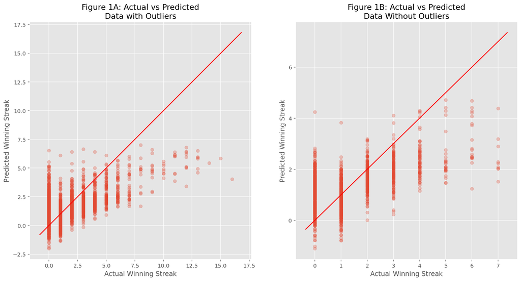

```python
def plot_line(axis, slope, intercept, **kwargs):
        xmin, xmax = axis.get_xlim()
        axis.plot([xmin, xmax], [xmin*slope+intercept, xmax*slope+intercept], **kwargs)

fig, (ax1, ax2) = plt.subplots(1,2)
fig.set_size_inches(16,8)

ax1.scatter(residuals_full['actual'], residuals_full['predicted'], alpha=0.3);
plot_line(axis=ax1,  slope=1, intercept=0, c='red')
ax1.set_xlabel('Actual Winning Streak')
ax1.set_ylabel('Predicted Winning Streak')
ax1.set_title('Figure 1A: Actual vs Predicted\nData with Outliers')

ax2.scatter(residuals_full_wo['actual'], residuals_full_wo['predicted'], alpha=0.3);
plot_line(axis=ax2,  slope=1, intercept=0, c='red')
ax2.set_xlabel('Actual Winning Streak')
ax2.set_ylabel('Predicted Winning Streak')
ax2.set_title('Figure 1B: Actual vs Predicted\nData Without Outliers')
plt.show()
```

Before we proceed to further interpret the regression outcomes, it would be sapient to check whether the regression assumptions have been met.

### Full Model Diagnostic Checks

Now that we have our full models, we will check whether they meet the following four assumptions for multiple regression:

1. the residuals of the model are nearly normal,
2. the residuals against the fitted values plot illustrates constant variability,
3. the residuals against the time feature plot feature shows no pattern (independence),
4. each independent variable is linearly related to the outcome.

#### Normal Distribution Condition

Let us first check the first assumption by plotting histograms of residuals and their Q-Q plots.

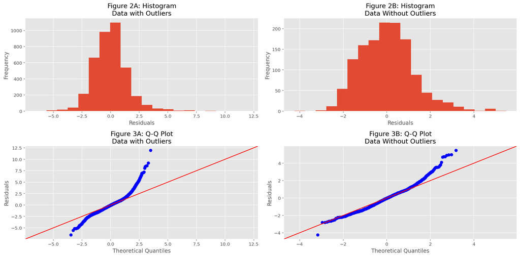

```python
fig, ((ax1, ax2), (ax3, ax4)) = plt.subplots(2,2)

fig.set_size_inches(16,8)

ax1.hist(residuals_full['residual'], bins= 20);
ax1.set_title('Figure 2A: Histogram\nData with Outliers')
ax1.set(xlabel='Residuals', ylabel='Frequency')

ax2.hist(residuals_full_wo['residual'], bins= 20);
ax2.set_title('Figure 2B: Histogram\nData Without Outliers')
ax2.set(xlabel='Residuals', ylabel='Frequency')

sm.qqplot(residuals_full['residual'], line='45', ax=ax3)
ax3.set_title('Figure 3A: Q-Q Plot\nData with Outliers')
ax3.set(xlabel='Theoretical Quantiles', ylabel='Residuals')
sm.qqplot(residuals_full_wo['residual'], line='45', ax=ax4)
ax4.set_title('Figure 3B: Q-Q Plot\nData Without Outliers')
ax4.set(xlabel='Theoretical Quantiles', ylabel='Residuals')

fig.tight_layout(pad=1.0)

plt.show()
```

The histograms above belie non-normally distributed residuals, which are more evident in the Q-Q plots where the end points do not overlie the straight red lines, but scatter significantly away. As stated in the textbook, we can cautiously dismiss these results as being less important given the large sizes of our datasets.

#### Constant Variability Condition

We shall check for homoscedasticity across absolute-residuals-against-fitted-values plots with LOWESS lines drawn through them.

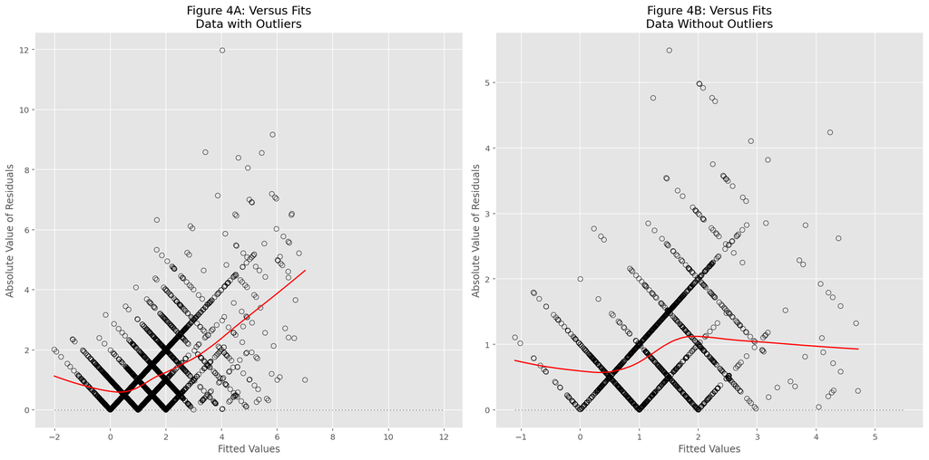

```python
full_residuals = abs(residuals_full['residual'])
full_fitted = residuals_full['predicted']

full_residuals_wo = abs(residuals_full_wo['residual'])
full_fitted_wo = residuals_full_wo['predicted']

from statsmodels.nonparametric.smoothers_lowess import lowess
smoothed = lowess(full_residuals, full_fitted)
smoothed_wo = lowess(full_residuals_wo, full_fitted_wo)

fig, (ax1, ax2) = plt.subplots(1,2)
fig.set_size_inches(16,8)
ax1.scatter(full_fitted, full_residuals, edgecolors = 'k', facecolors = 'none')
ax1.plot(smoothed[:,0], smoothed[:,1], color = 'r')
ax1.set_title('Figure 4A: Versus Fits\nData with Outliers')
ax1.set_xlabel('Fitted Values')
ax1.set_ylabel('Absolute Value of Residuals')
ax1.plot([min(full_fitted), max(full_residuals)], [0,0], color = 'k', linestyle = ':', alpha = .3)

ax2.scatter(full_fitted_wo, full_residuals_wo, edgecolors = 'k', facecolors = 'none')
ax2.plot(smoothed_wo[:,0], smoothed_wo[:,1], color = 'r')
ax2.set_title('Figure 4B: Versus Fits\nData Without Outliers')
ax2.set_xlabel('Fitted Values')
ax2.set_ylabel('Absolute Value of Residuals')
ax2.plot([min(full_fitted_wo), max(full_residuals_wo)], [0,0], color = 'k', linestyle = ':', alpha = .3)

fig.tight_layout(pad=1.0)

plt.show()
```

We observe that the left plot from the outlier-model exhibits non-constant variability. In comparison to it, the dots from the without-outlier-model are scattered with more constant variability, but far from the ideal homoscedasticity with the lump in the middle of the lowess line in Figure 4B.

#### Independence Condition

Let us now plot residuals against the time feature for both of the datasets.

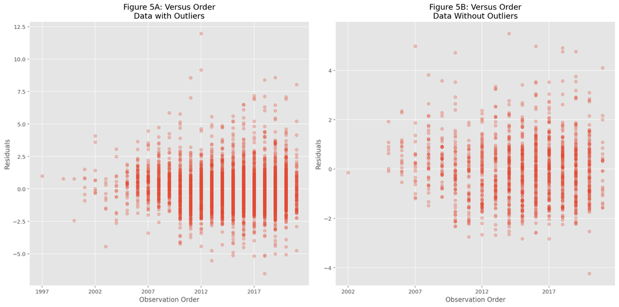

```python
fig, (ax1, ax2) = plt.subplots(1, 2)
fig.set_size_inches(16,8)

ax1.scatter(df_date['date'], residuals_full['residual'], alpha=0.3)
ax1.set_title('Figure 5A: Versus Order\nData with Outliers')
ax1.set_xlabel('Observation Order')
ax1.set_ylabel('Residuals')
ax1.xaxis.set_ticks(np.arange(df_date['date'].min(), df_date['date'].max(), 5))

ax2.scatter(df_date_wo['date'], residuals_full_wo['residual'], alpha=0.3)
ax2.set_title('Figure 5B: Versus Order\nData Without Outliers')
ax2.set_xlabel('Observation Order')
ax2.set_ylabel('Residuals')
ax2.xaxis.set_ticks(np.arange(df_date_wo['date'].min(), df_date_wo['date'].max(), 5))

fig.tight_layout(pad=1.0)

plt.show()
```

As there are no evident patterns in the above plots, we can assume that the observations in our datasets are indeed independent.

### Feature Selection

Our full models contained many features with p-values greater than the significance level of 0.05, indicating many of the terms are statistically insignificant. We now perform backward elimination on our full models with the p-value approach.

```python
def backward_feature_selection(fse, mff, dfe):
    ## create the patsy model description from formula
    patsy_description = patsy.ModelDesc.from_formula(fse)

    # initialize feature-selected fit to full model
    linreg_fit = mff

    # do backwards elimination using p-values
    p_val_cutoff = 0.05

    ## WARNING 1: The code below assumes that the Intercept term is present in the model.
    ## WARNING 2: It will work only with main effects and two-way interactions, if any.

    print('\nPerforming backwards feature selection using p-values:')

    while True:
        pval_series = linreg_fit.pvalues.drop(labels='Intercept')
        pval_series = pval_series.sort_values(ascending=False)
        term = pval_series.index[0]
        pval = pval_series[0]
        if (pval < p_val_cutoff):
            break
        term_components = term.split(':')
        print(f'\nRemoving term "{term}" with p-value {pval:.4}')
        if (len(term_components) == 1): ## this is a main effect term
            patsy_description.rhs_termlist.remove(patsy.Term([patsy.EvalFactor(term_components[0])]))
        else: ## this is an interaction term
            patsy_description.rhs_termlist.remove(patsy.Term([patsy.EvalFactor(term_components[0]),
                                                        patsy.EvalFactor(term_components[1])]))
        linreg_fit = smf.ols(formula=patsy_description, data=dfe).fit()

    ## this is the clean fit after backwards elimination
    model_reduced_fitted = smf.ols(formula = patsy_description, data = dfe).fit()
    #########
    print("\n***")
    print(model_reduced_fitted.summary())
    print("***")
    print(f"Regression number of terms: {len(model_reduced_fitted.model.exog_names)}")
    print(f"Regression F-distribution p-value: {model_reduced_fitted.f_pvalue:.4f}")
    print(f"Regression R-squared: {model_reduced_fitted.rsquared:.4f}")
    print(f"Regression Adjusted R-squared: {model_reduced_fitted.rsquared_adj:.4f}")

    return model_reduced_fitted

model_reduced_fitted = backward_feature_selection(formula_string_encoded, model_full_fitted, df_encoded)
model_reduced_fitted_wo = backward_feature_selection(formula_string_encoded_wo, model_full_fitted_wo, df_encoded_wo)
```

```
Performing backwards feature selection using p-values:

Removing term "b_avg_opp_td_landed" with p-value 0.9996

Removing term "weight_class_Middleweight" with p-value 0.9825

Removing term "r_avg_opp_sub_att" with p-value 0.9554

Removing term "b_avg_kd" with p-value 0.9476

Removing term "b_stance_Southpaw" with p-value 0.9478

Removing term "weight_class_WomenFlyweight" with p-value 0.9413

Removing term "b_win_by_ko_tko" with p-value 0.941

Removing term "r_avg_td_att" with p-value 0.939

Removing term "r_avg_body_landed" with p-value 0.9343

Removing term "r_avg_opp_td_pct" with p-value 0.9076

Removing term "weight_class_LightHeavyweight" with p-value 0.8921

Removing term "r_avg_td_pct" with p-value 0.8841

Removing term "weight_class_WomenBantamweight" with p-value 0.8731

Removing term "b_total_title_bouts" with p-value 0.843

Removing term "r_avg_clinch_landed" with p-value 0.8138

Removing term "r_stance_Southpaw" with p-value 0.7617

Removing term "b_avg_opp_kd" with p-value 0.7127

Removing term "b_avg_opp_leg_att" with p-value 0.6893

Removing term "b_avg_rev" with p-value 0.6955

```

[output cut: 320 more lines]

```
Omnibus:                      105.407   Durbin-Watson:                   1.947
Prob(Omnibus):                  0.000   Jarque-Bera (JB):              154.441
Skew:                           0.619   Prob(JB):                     2.91e-34
Kurtosis:                       4.116   Cond. No.                     7.74e+03
==============================================================================

Notes:
[1] Standard Errors assume that the covariance matrix of the errors is correctly specified.
[2] The condition number is large, 7.74e+03. This might indicate that there are
strong multicollinearity or other numerical problems.
***
Regression number of terms: 26
Regression F-distribution p-value: 0.0000
Regression R-squared: 0.2922
Regression Adjusted R-squared: 0.2787
```

### Reduced Model Overview

Our reduced models will only include the terms deemed statistically significant from the selection above. Below are the regression equations.

1. Reduced Model with Outliers ($R_{adj}^{2}$: 0.332)

$$\hat{r\_post\_fight\_win\_streak} = 1.566 + title\_bout \times 1.68 + b\_avg\_td\_att \times -0.04 + b\_avg\_opp\_td\_att \times -0.026 + b\_avg\_opp\_body\_landed \times 0.01 + b\_avg\_leg\_att \times -0.009 + b\_current\_win\_streak \times -0.049 + b\_reach\_cms \times -0.008 + r\_avg\_kd \times 0.198 + r\_avg\_opp\_kd \times -0.301 + r\_avg\_opp\_sig\_str\_pct \times -1.477 + r\_avg\_sub\_att \times 0.191 + r\_avg\_rev \times -0.199 + r\_avg\_opp\_td\_att \times 0.046 + r\_avg\_opp\_head\_att \times -0.004 + r\_avg\_leg\_landed \times 0.02 + r\_avg\_ground\_att \times 0.014 + r\_avg\_ctrl\_time\_seconds \times 0.001 + r\_avg\_opp\_ctrl\_time\_seconds \times -0.001 + r\_total\_title\_bouts \times 0.048 + r\_current\_lose\_streak \times -0.211 + r\_losses \times -0.202 + r\_win\_by\_decision\_majority \times -0.313 + r\_win\_by\_decision\_unanimous \times 0.124 + r\_win\_by\_ko\_tko \times 0.139 + r\_win\_by\_submission \times 0.174 + r\_reach\_cms \times 0.011 + b\_age \times 0.023 + r\_age \times -0.024 + weight\_class_{Heavyweight} \times -0.264$$

1. Reduced Model Without Outliers ($R_{adj}^{2}$: 0.279)

$$\hat{r\_post\_fight\_win\_streak} = 3.492 + b\_avg\_opp\_td\_pct \times 0.392 + b\_avg\_td\_att \times -0.044 + b\_avg\_body\_landed \times -0.017 + b\_avg\_opp\_ground\_landed \times 0.019 + b\_current\_lose\_streak \times -0.248 + b\_win\_by\_decision\_split \times 0.174 + b\_win\_by\_decision\_unanimous \times -0.084 + b\_reach\_cms \times -0.016 + r\_avg\_kd \times 0.339 + r\_avg\_opp\_sig\_str\_pct \times -1.144 + r\_avg\_sub\_att \times 0.2 + r\_avg\_opp\_td\_att \times 0.059 + r\_avg\_body\_att \times -0.017 + r\_avg\_ctrl\_time\_seconds \times 0.001 + r\_avg\_opp\_ctrl\_time\_seconds \times -0.002 + r\_current\_lose\_streak \times -0.299 + r\_losses \times -0.134 + r\_win\_by\_decision\_unanimous \times 0.104 + r\_win\_by\_ko\_tko \times 0.17 + r\_win\_by\_submission \times 0.085 + r\_reach\_cms \times 0.011 + b\_age \times 0.021 + r\_age \times -0.046 + title\_bout \times 1.731 + b\_stance_{Switch} \times -0.35$$

Even though there is a slight improvement in the $R_{adj}^{2}$ of the reduced model from the full model, we need to ensure the model assumptions are met before trusting our statistical results.

Below, we get a sample of 5 observations from each of the reduced models to compare actual values to predicted values.

```python
residuals_reduced = pd.DataFrame({'actual': df_encoded['r_post_fight_win_streak'],
                                 'predicted': model_reduced_fitted.fittedvalues,
                                 'residual': model_reduced_fitted.resid})

residuals_reduced.sample(5, random_state=999)
```

| r_fighter | b_fighter | actual | predicted | residual |
| --- | --- | --- | --- | --- |
| Mike Guymon | Daniel Roberts | 0.0 | 1.526 | -1.526 |
| Daniel Roberts | Claude Patrick | 0.0 | 1.778 | -1.778 |
| Ryan Bader | Carmelo Marrero | 2.0 | 2.179 | -0.179 |
| Kyung Ho Kang | Guido Cannetti | 3.0 | 1.837 | 1.163 |
| George Sotiropoulos | Joe Lauzon | 7.0 | 2.362 | 4.638 |

```python
residuals_reduced_wo = pd.DataFrame({'actual': df_encoded_wo['r_post_fight_win_streak'],
                                 'predicted': model_reduced_fitted_wo.fittedvalues,
                                 'residual': model_reduced_fitted_wo.resid})

residuals_reduced_wo.sample(5, random_state=999)
```

| r_fighter | b_fighter | actual | predicted | residual |
| --- | --- | --- | --- | --- |
| Wilson Gouveia | Ryan Jensen | 1.0 | 1.558 | -0.558 |
| Warlley Alves | Sultan Aliev | 2.0 | 1.584 | 0.416 |
| Amanda Nunes | Valentina Shevchenko | 6.0 | 4.377 | 1.623 |
| Jack Hermansson | Alex Nicholson | 1.0 | 0.730 | 0.270 |
| Marvin Eastman | Terry Martin | 1.0 | -0.776 | 1.776 |

#### Analysis of Regression Results

We will again plot the predicted values against the actual values to evaluate the precision of our reduced models.

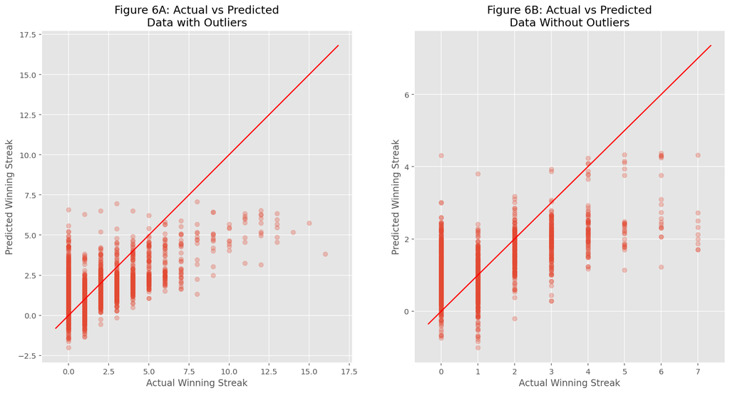

```python
def plot_line(axis, slope, intercept, **kwargs):
        xmin, xmax = axis.get_xlim()
        axis.plot([xmin, xmax], [xmin*slope+intercept, xmax*slope+intercept], **kwargs)

fig, (ax1, ax2) = plt.subplots(1,2)
fig.set_size_inches(16,8)

ax1.scatter(residuals_reduced['actual'], residuals_reduced['predicted'], alpha=0.3);
plot_line(axis=ax1,  slope=1, intercept=0, c='red')
ax1.set_xlabel('Actual Winning Streak')
ax1.set_ylabel('Predicted Winning Streak')
ax1.set_title('Figure 6A: Actual vs Predicted\nData with Outliers')

ax2.scatter(residuals_reduced_wo['actual'], residuals_reduced_wo['predicted'], alpha=0.3);
plot_line(axis=ax2,  slope=1, intercept=0, c='red')
ax2.set_xlabel('Actual Winning Streak')
ax2.set_ylabel('Predicted Winning Streak')
ax2.set_title('Figure 6B: Actual vs Predicted\nData Without Outliers')
plt.show()
```

Our reduced models still underestimate the values of the dependent feature when they should be greater and overestimate them when they should be a lot less.

### Reduced Model Diagnostic Checks

As with the full models, we will run model diagnostic checks to see whether our reduced models still violate the assumptions as seen in the full model diagnostic checks.

#### Normal Distribution Condition

Even though OLS does not necessitate a normal distribution of residuals to make unbiased predictions with the minimum variance, we will again check for this condition as part of our diagnostics.

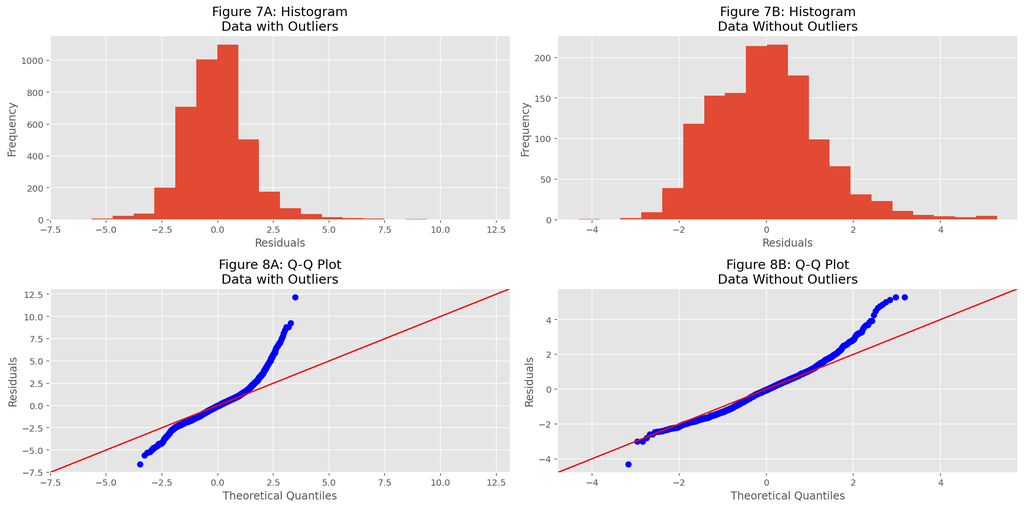

```python
fig, ((ax1, ax2), (ax3, ax4)) = plt.subplots(2,2)

fig.set_size_inches(16,8)

ax1.hist(residuals_reduced['residual'], bins= 20);
ax1.set_title('Figure 7A: Histogram\nData with Outliers')
ax1.set(xlabel='Residuals', ylabel='Frequency')

ax2.hist(residuals_reduced_wo['residual'], bins= 20);
ax2.set_title('Figure 7B: Histogram\nData Without Outliers')
ax2.set(xlabel='Residuals', ylabel='Frequency')

sm.qqplot(residuals_reduced['residual'], line='45', ax=ax3)
ax3.set_title('Figure 8A: Q-Q Plot\nData with Outliers')
ax3.set(xlabel='Theoretical Quantiles', ylabel='Residuals')
sm.qqplot(residuals_reduced_wo['residual'], line='45', ax=ax4)
ax4.set_title('Figure 8B: Q-Q Plot\nData Without Outliers')
ax4.set(xlabel='Theoretical Quantiles', ylabel='Residuals')

fig.tight_layout(pad=1.0)

plt.show()
```

The Q-Q plots closely resemble their counterparts for the full models.

#### Constant Variability Condition

We will check again for constant variability by plotting absolute values of residuals against fitted values.

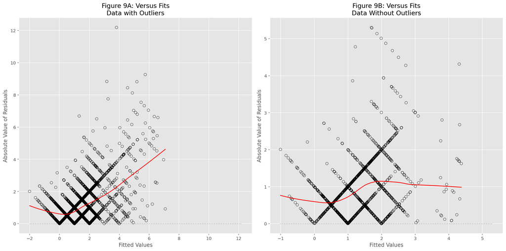

```python
reduced_residuals = abs(residuals_reduced['residual'])
reduced_fitted = residuals_reduced['predicted']

reduced_residuals_wo = abs(residuals_reduced_wo['residual'])
reduced_fitted_wo = residuals_reduced_wo['predicted']

from statsmodels.nonparametric.smoothers_lowess import lowess
smoothed = lowess(reduced_residuals, reduced_fitted)
smoothed_wo = lowess(reduced_residuals_wo, reduced_fitted_wo)

fig, (ax1, ax2) = plt.subplots(1,2)
fig.set_size_inches(16,8)
ax1.scatter(reduced_fitted, reduced_residuals, edgecolors = 'k', facecolors = 'none')
ax1.plot(smoothed[:,0], smoothed[:,1], color = 'r')
ax1.set_title('Figure 9A: Versus Fits\nData with Outliers')
ax1.set_xlabel('Fitted Values')
ax1.set_ylabel('Absolute Value of Residuals')
ax1.plot([min(reduced_fitted), max(reduced_residuals)], [0,0], color = 'k', linestyle = ':', alpha = .3)

ax2.scatter(reduced_fitted_wo, reduced_residuals_wo, edgecolors = 'k', facecolors = 'none')
ax2.plot(smoothed_wo[:,0], smoothed_wo[:,1], color = 'r')
ax2.set_title('Figure 9B: Versus Fits\nData Without Outliers')
ax2.set_xlabel('Fitted Values')
ax2.set_ylabel('Absolute Value of Residuals')
ax2.plot([min(reduced_fitted_wo), max(reduced_residuals_wo)], [0,0], color = 'k', linestyle = ':', alpha = .3)

fig.tight_layout(pad=1.0)

plt.show()
```

One of the assumptions for linear regression is that the scatter of the residuals is constant throughout the plot. Its violation warrants wariness of predicted outcomes. Given the lowess lines, we have a good reason to believe the assumption for constant variability is not met for both of the reduced models.

## Critique & Limitations

All of our models, regardless of whether outliers are present and both full and reduced, overestimated the actual values when they should be 0; the predicted winning streaks also included negative values, at odds with the minimum value of a winning streak in real life: 0. They also underestimated for the majority of the time, if not all the time, when the actual winning streak is greater than 2. Since the response variable is discrete and is limited to non-negative values, a Poisson regression or one of its variants should instead have been used to fit data (Grace-Martin, n.d.).

The outliers-models also clearly exhibited non-constant variability, an indication that models other than linear regression may result in a better fit. The no-outliers-models were more constant in variability than their counterparts, but the graphs 4B and 9B still beg the question of whether different models should be tried for results that can be trusted.

## Summary & Conclusions

### Project Summary

In Phase 1, we have corrected or dropped any odd or unusual values in our original dataset. After that, we also made sure to drop irrelevant columns. Moreover, instead of removing all the outliers, we created two datasets, one with outliers kept and the other without them so that we can decide on which dataset to use based on the model fitting during Phase 2. Once the dataset is preprocessed for Phase 2, it and its variants were graphically mapped onto plots in an attempt to understand correlations between the dependent and independent variables.

In Phase 2, before proceeding to build our full models based on the two datasets, we dropped features suspected to contribute to multicollinearity based on their high VIFs. We then went on to build our full models, perform a quick analysis on the regression results, and run diagnostics to check whether the model conditions were met. Our full models were reshaped into reduced models by backward elimination with the p-value approach. The same process after generating the full models was then repeated for the reduced models. Finally, we further discussed the violations of the linear assumptions and the limitations of our models.

### Summary of Findings

Based on Figure 9A and 9B, we have decided to dispense with the outliers-model and report our findings from the no-outliers, reduced model.

As mentioned in the critique section, the biggest finding is that our dataset would have been fit better using different models such as Poisson, Neural Networks, etc.

### Conclusions

In Phase 1, we set out to unearth some magic equation that can reveal all the intricate correlations behind winning streaks. Although we have gained superficial insight into some of the correlations in Phase 1, we have come to a dead end using our linear regression model.

MMA fighting has numerous dependent features that can be extremely difficult to capture. For instance, the average physical response time of a fighter may be one of the most import attributes needed to gauge the winning probability of a fighter. Such data will surely be made available in the future as we have more tools to analyse fight footages. We shall come back to this question we set out to answer at the beginning of our report once our understanding of machine learning analytics matures and there are more terms (data) we can leverage.

## References

Frost, J. (n.d.). Multicollinearity in Regression Analysis: Problems, Detection, and Solutions. Statistics By Jim. Retrieved October 10, 2021, from https://statisticsbyjim.com/regression/multicollinearity-in-regression-analysis/

Grace-Martin, K. (n.d.). Regression Models for Count Data. Retrieved November 4, 2021, from https://www.theanalysisfactor.com/regression-models-for-count-data/

Frost, J. (n.d.). Heteroscedasticity in Regression Analysis. Retrieved November 4, 2021, from https://statisticsbyjim.com/regression/heteroscedasticity-regression